# act_report

## Report: act_report

## Exploring the WeLoveDogs Twitter Page

### Three Unique Insights from WeLoveDogs.

**1. What are the top 10 most popular dog names in our dataset?**  
**2. What breed of dog is tweeted about the most?**  
**3. Does a higher rating mean a larger amount of retweets?**

From the data provided to us via twitter, we've been able to explore the three questions above. Let's begin with the first question, what are the top 10 most popular dog names in our dataset? Although, a quick google search can give us the most popular dog names we want to understand, what are the most popular dog names specifically for this twitter account dedicated to dogs? After exploring the dataset we've been able to gather from twitter, the answer is Lucy. 11 dogs out of the 2174 dogs in our dataset were named Lucy. However, it is important to clarify that 11 dogs were also named Charlie. Although it is nice seeing their names, let's look at what some of our top 10 dogs look like.

**This is one of our dogs named Lucy.**

[figure not shown]

**And this is one of our dogs named Charlie.**

[figure not shown]

Now that we know what name is the most popular, what about the breed? Thanks to our dataset, we've found the answer! Golden retrievers are the most tweeted about breed in WeLoveDogs. Which does make sense, it is one of the most generally known dog breeds thanks to Air Bud.

### Here's our Top 10 List of Dog Breeds on WeLoveDogs.

1. Golden Retriever

[figure not shown]

1. Labrador Retriever

[figure not shown]

1. Pembroke Welsh Corgi

[figure not shown]

1. Chihuahua

[figure not shown]

1. Pug

[figure not shown]

1. Chow Chow

[figure not shown]

1. Pomeranian

[figure not shown]

1. Toy Poodle

[figure not shown]

1. Samoyed

[figure not shown]

1. Alaskan Malamute

[figure not shown]

Lastly, since the purpose of WeLoveDogs is to rate the dogs apart from just tweeting about them, we asked, 'Does a higher rating mean a larger amount of retweets?'. The answer, not neccesarily. Judging from our graph below we can see that a rating of 0,64 is the most retweeted dog rating with 0.82 coming in second. However, even though one dog recieved a rating of 177.6 it wasn't the most retweeted.

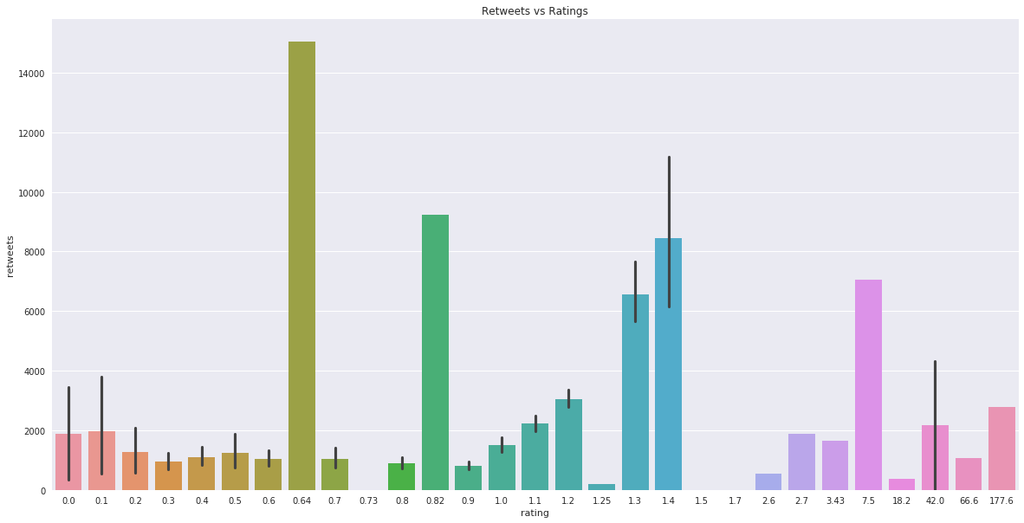